# Organismal Responses to Change: Adjust

## The Adjacent Possible

**Confronted with a changing world, organisms can move, adjust, adapt, or die**

**In physical space -> move**

**In physiological / behavioral space -> adjust**

**In genetic / adaptive space -> adapt**

**If no adjacent possible -> die**

**Responses are not mutually exclusive**

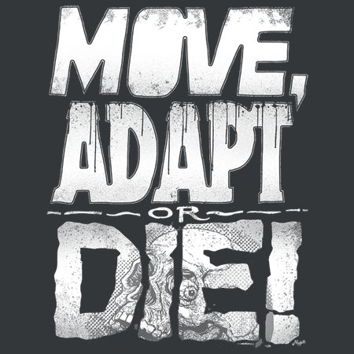

## The Adjacent Possible for other species

**If environmental conditions are changing…**

- **What are the adjacent possible options for survival?**
- **What determines the adjacent possible?**
  - Organismal traits
  - Environmental features
  - Dynamics of change
- **Can a trait be adjusted?**
  - reminder: traits can be morphological, structural, or physiological

[figure not shown]

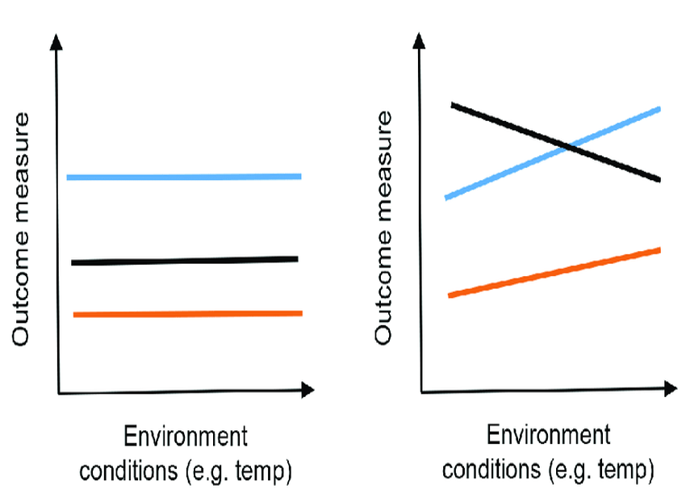

## Organismal responses to change: Adjust

- **Adjust: non-genetic shifts in organismal traits in different environments**
  - *phenotypic plasticity*, acclimation, acclimitization
- **Adjust response happens at the *individual* level and within a *single* generation**
  - What does this mean?

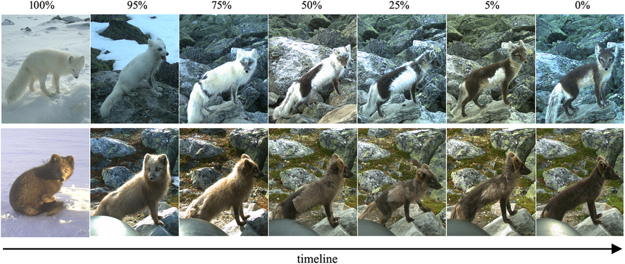

## Organismal responses to change: Adjust

**Genotype: inherited genetic information**

**Phenotype: observable traits or characteristics**

**What is the connection between genotype & phenotype?**

**Genotype x Environment = Phenotype variation?**

**G x E interactions are the foundation of phenotypic plasticity**

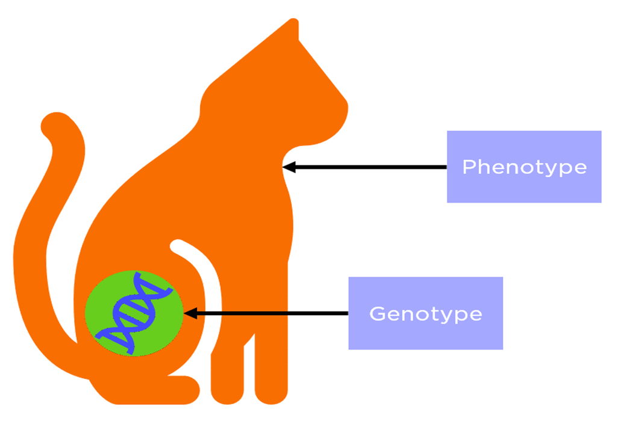

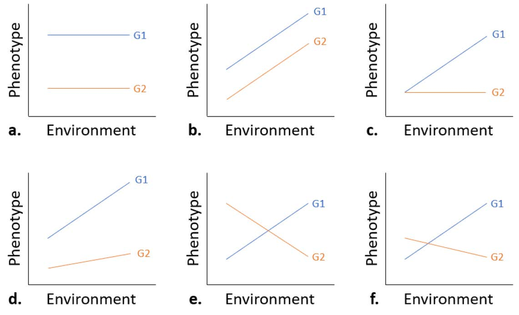

## What is phenotypic plasticity?

**When a single genotype can produce multiple phenotypes depending on environmental conditions**

- **Inducible defenses are classic examples**
  - animals and plants
  - often fast
  - not needed when predators are absent
  - dedicated sensory systems to interpret the environment
- **Daphnia (small crustacean) produce horns and neck teeth in presence of predators**
  - Why not just express horns all the time?

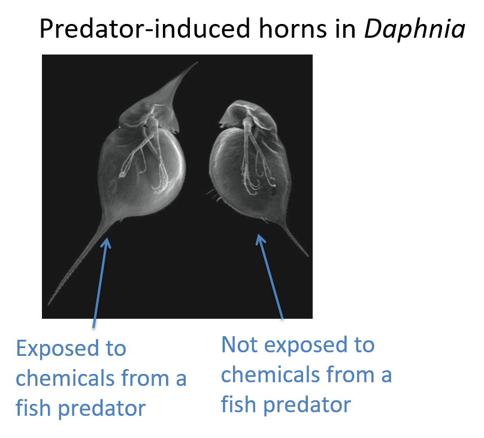

## Density-induced grasshopper plasticity

**Plasticity can occur as a specturm of changes in a trait (not just off or on)**

**Grasshopper camoflauge and behavior is influenced by ‘crowdedness’**

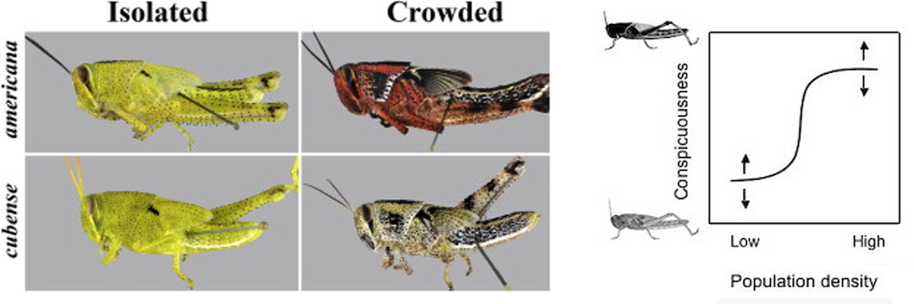

## Some shore crabs change colors during the day!

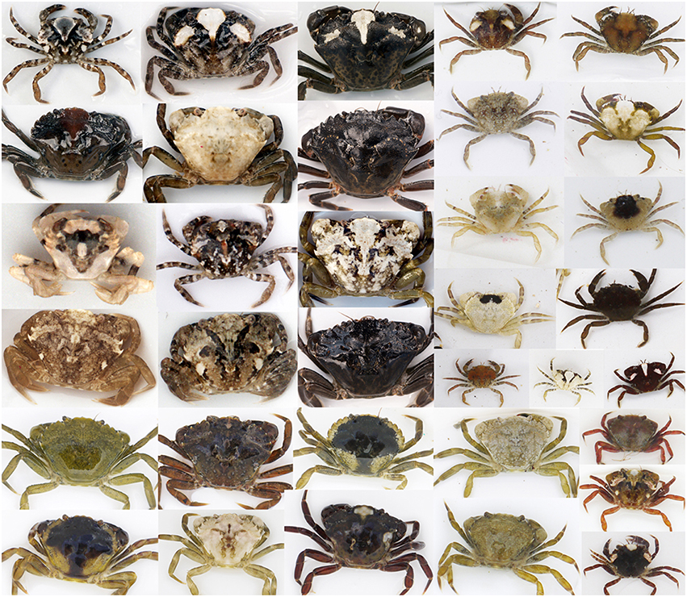

**Camouflage**

**Temperature regulation**

**Signaling for mating/competition**

**UV light protection**

## What is phenotypic plasticity?

**When a single genotype can produce multiple phenotypes depending on environmental conditions**

- **Plasticity doesn’t have to be for morphological traits.**
- **Physiological, developmental and behavioral traits can also exhibit plasticity**
- **Behavior has long been considered the ‘most plastic’ phenotypic trait**
  - quickest response to temporal changes
  - e.g., bird song frequency in urban environments

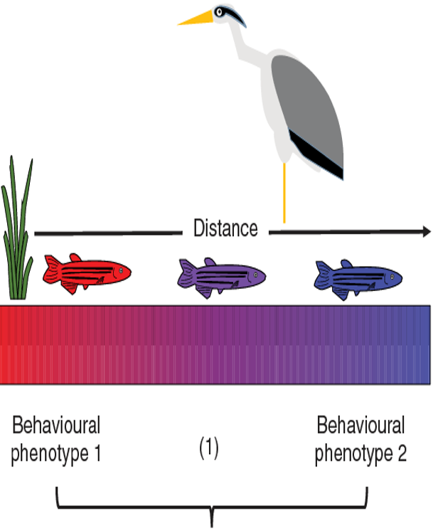

## Bird songs vs river and ocean surf noise

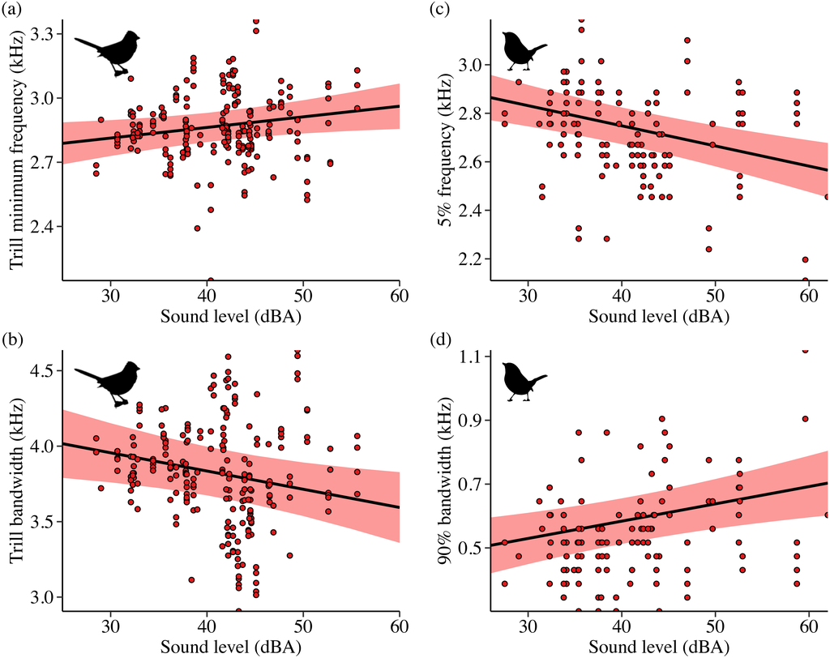

## What is phenotypic plasticity?

**When a single genotype can produce multiple phenotypes depending on environmental conditions**

- **Developmental plasticity: the ability of an individual to modify its development in response to environmental conditions**
  - might facilitate the evolution of novel traits
- **How developmental flexibility promotes innovations that persist over evolutionary time is unclear**
- **However, exposure to environmental variation is a characteristic feature of normal development**
  - do certain genotypes have the ability to produce different development outcomes?

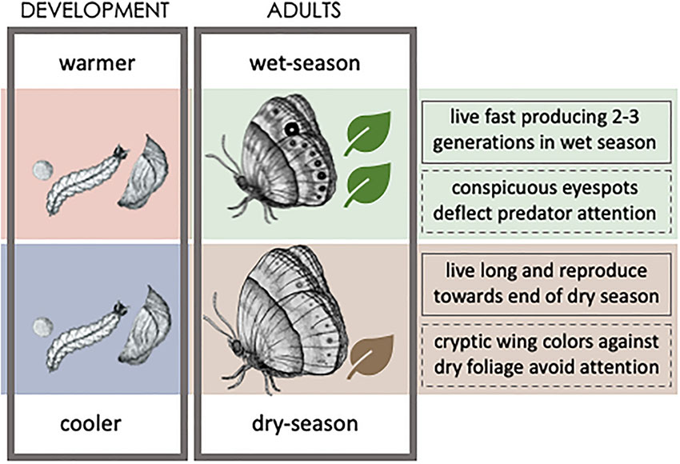

## Plasticity in monarch butteflies: Migratory syndrome

- **Environmental triggers (day length/cold) drigger the migratory state**
  - development of reproductive organs is stopped
  - ageing is suppressed
  - accumulate more fat to fuel

**Migratory state triggers behavioral instinct to fly south**

**In captivity, monarchs can lose these migratory traits (NO GxE)**

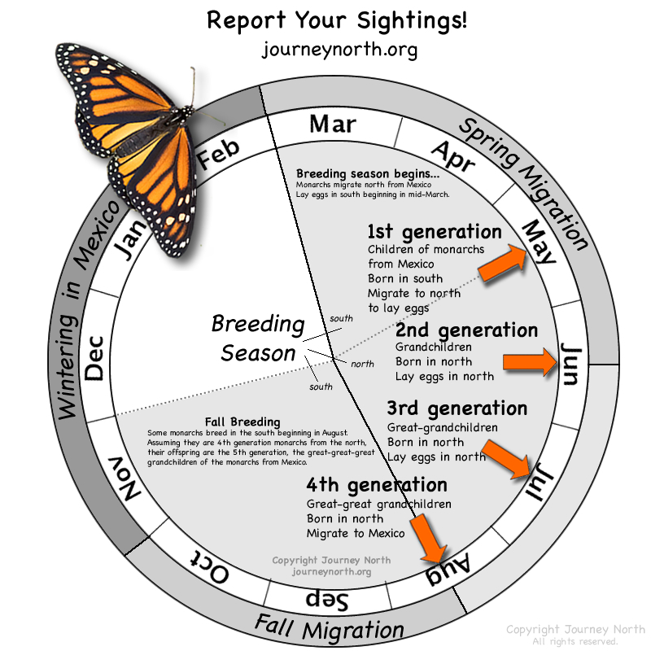

## Are all traits plastic?

- **Optimal responses to environmental challenges would include perfect plasticity**
  - organism possesses perfect information on its current environment
  - mechanisms to produce an appropriate phenotypic response at all points in development
- **Instead, traits exist on a spectrum that are determined exclusively by genetics and those influenced mostly by the environment**
  - no organism is entirely or infinitely plastic
  - what is the cost to evolving plasticity?
- **Interesting point: Organisms in heterogeneous (variable) environments are more likely to have selection of traits that can be plastic**
  - low genetic diversity can limit selection of plastic traits

## How do you test for phenotypic plasticity?

**How do you figure out if a trait is controlled by genes, the environment or both?**

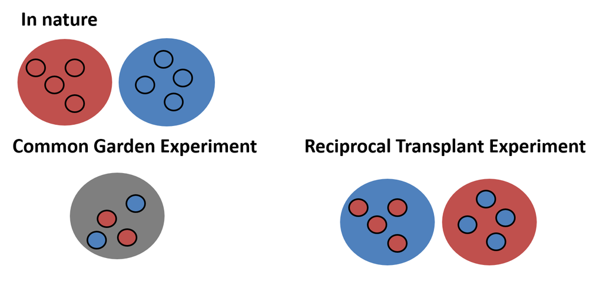

## How do you test for phenotypic plasticity?

**Effect of genotype only (not phenotypically plastic under these conditions)**

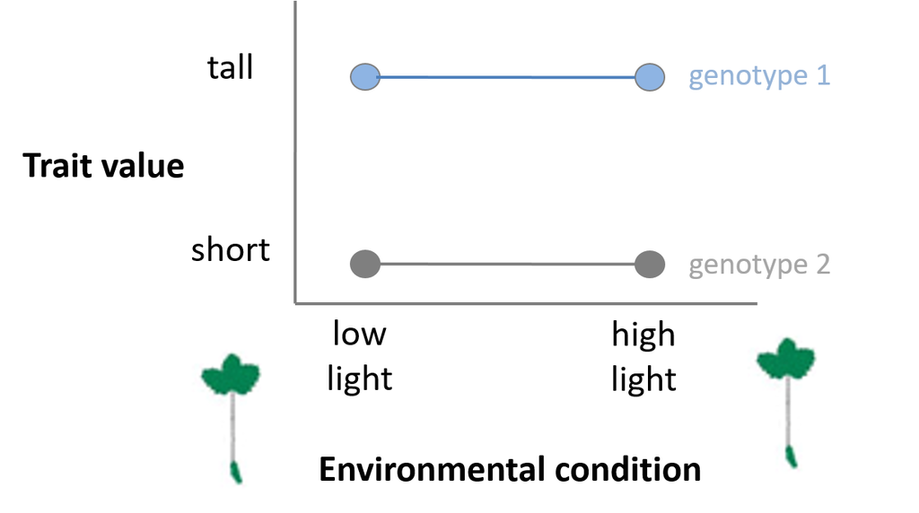

## How do you test for phenotypic plasticity?

**Effect of environment only (YES phenotypically plastic under these conditions)**

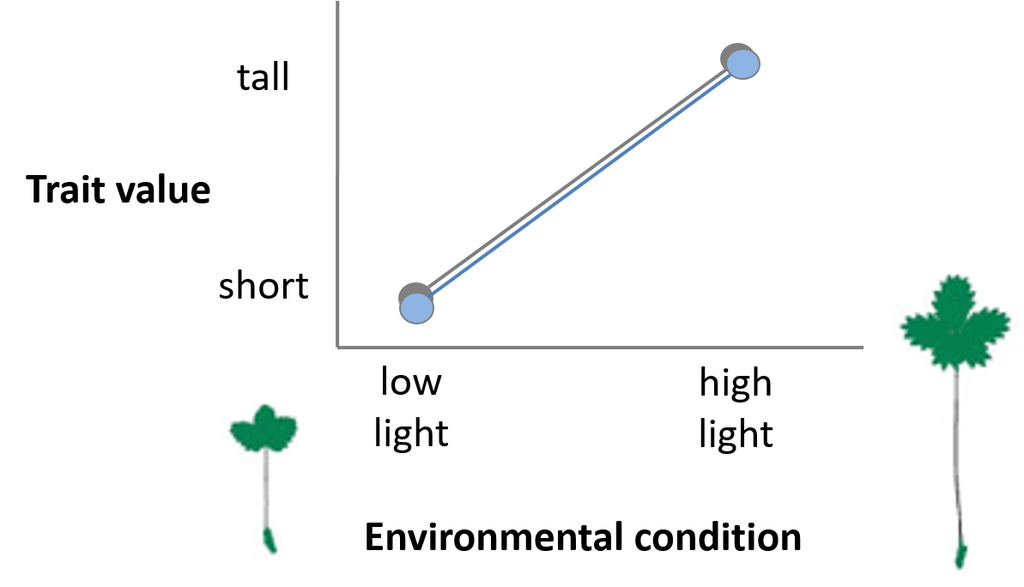

## How do you test for phenotypic plasticity?

**Effect of both environment and genotype (genotype by environment interaction)**

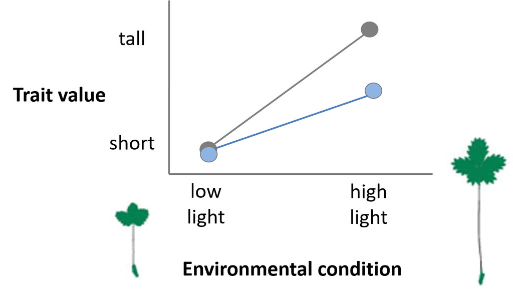

## Are global change and the adjust response compatible?

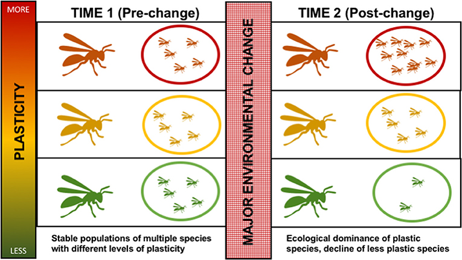

## Are global change and the adjust response compatible?

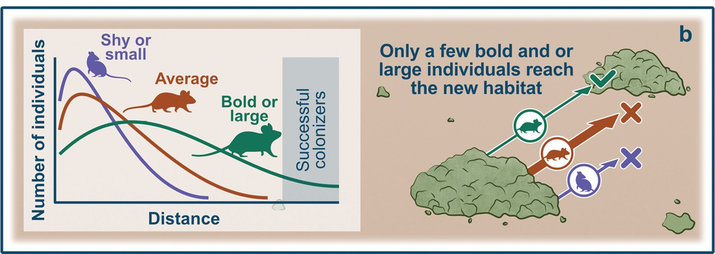